# Coding Assignment 3

CS598: Practical Statistical Learning

Naomi Bhagat - nbhagat3

Michael Miller - msmille3

Joe May - jemay3

07 October 2023

# Assignment Data

Program: MCS-DS  
Team contributions:

| Person | Contribution |
| --- | --- |
| Naomi Bhagat | Part 1 |
| Michael Miller | Part 2 & 3 |
| Joe May | Part 3/Quality Assurance |

Assignment URL: [campuswire post](https://campuswire.com/c/G06C55090/feed/242)

```r
# add required packages
packages = c('splines')

# if packages don't exist, install. Then call library on them
for (package in packages) {
  if (!requireNamespace(package, quietly=TRUE)) {
    install.packages(package)
  }
  library(package, character.only=TRUE)
}

# set seed
set.seed(235)
```

# Part 1: Optimal Span for LOESS

## Part 1-1: Computing the Diagonal of the Smoother Matrix

Create a function to retrieve the diagonal of the smoother matrix. We’re only interested in the diagonal entries (which will be used in computing LOO-CV and GCV), so this function should return an n-by-1 vector. - Inputs: x (an n-by-1 feature vector) and span (a numerical value). - Output: n-by-1 vector representing the diagonal of the smoother matrix S. - Tip: Review the technique we used for the smoother matrix in smoothing spline models and adapt it for LOESS.

```r
get_diag = function(x, span) {
  # x: n-by-1 feature vector
  # span: numerical value for span

  n = length(x)

  # return vector d (diagonal)
  d = rep(0, n)

  # Smoothing matrix S
  S = diag(n)

  # Algorithm
  for(i in 1:n) {
    fit = loess(S[ , i] ~ x, span=span)
    y_hat = fit$fitted
    d[i] = y_hat[i]
  }

  return(d)
}
```

### Part 1-2

Span Value Iteration: - Iterate over the specified span values. - For each span, calculate the CV and GCV values. - Post iteration, compile lists of CV and GCV values corresponding to each span.

```r
span_value_iter = function(x, y, span) {
  n = length(x)
  num_span = length(span)

  # return value vectors
  cv = rep(0, num_span)
  gcv = rep(0, num_span)

  # Iterate over the span values
  for(s in 1:num_span) {
    # For each span, calculate cv and gcv values
    # First, fit the loess model
    fit = loess(y ~ x, span=span[s], control=loess.control(surface="direct"))
    residuals = fit$residuals
    d = get_diag(x, span[s])

    # intermediate calculations for cv and gcv
    # https://liangfgithub.github.io/Notes/lec_W5_NonlinearRegression.pdf slide 33
    tr = sum(d)
    sse = sum(residuals ^ 2)

    # calculate cv
    cv[s] = sum((residuals / (1 - d))^2) / n

    # calculate gcv
    gcv[s] = sse / (n * (1 - (tr / n)) ^ 2)
  }

  return(list(cv = cv, gcv = gcv))
}
```

### Part 1-3

1. Test your code using data set [Coding3_Data.csv]
2. Report your CV and GCV for the following 15 span values: 0.20, 0.25, . . . , 0.90.
3. Report the optimal span value(s) based on CV and GCV.
4. Display the original data points and overlay them with the true curve and the fitted curve(s) generated using the optimal span value(s).

The true curve is
$$f(x) =
\frac{\sin(12(x + 0.2))}{x + 0.2}$$

```r
part1_data = read.csv("Coding3_Data.csv")
test_span = c(0.2, 0.25, 0.3, 0.35, 0.4, 0.45, 0.5, 0.55, 0.6, 0.65, 0.7, 0.75, 0.8, 0.85, 0.9)
result = span_value_iter(part1_data$x, part1_data$y, test_span)

# Report cv, gcv values
output = data.frame(CV = result$cv, GCV = result$gcv, span = test_span)
output
```

```
##           CV      GCV span
## 1  12.418290 2.111673 0.20
## 2   2.241397 1.489157 0.25
## 3   1.502968 1.190103 0.30
## 4   1.225630 1.138079 0.35
## 5   1.139430 1.054972 0.40
## 6   1.114158 1.024551 0.45
## 7   1.088725 1.010398 0.50
## 8   1.165058 1.106761 0.55
## 9   1.170975 1.113361 0.60
## 10  1.223517 1.159140 0.65
## 11  1.221954 1.179681 0.70
## 12  1.260567 1.236074 0.75
## 13  1.451601 1.418852 0.80
## 14  1.746952 1.686762 0.85
## 15  1.832940 1.768050 0.90
```

```r
# Optimal cv values
cv_opt = output$span[output$CV == min(output$CV)]
cv_opt
```

```
## [1] 0.5
```

```r
# Optimal gcv values
gcv_opt = output$span[output$GCV == min(output$GCV)]
gcv_opt
```

```
## [1] 0.5
```

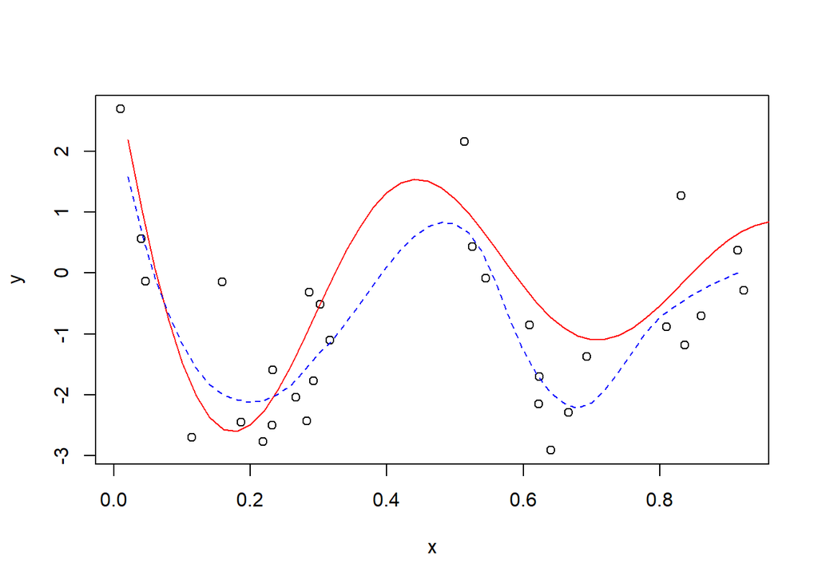

```r
# Plot curve
# Data + Control curve
plot(part1_data$x, part1_data$y, xlab="x", ylab="y")

fx = 1:50/50
fy = sin(12*(fx + 0.2)) / (fx + 0.2)
lines(fx, fy, col="red")

# My curve - cv
cv_f = loess(y ~ x, part1_data, span=cv_opt)
lines(fx, predict(cv_f, data.frame(x = fx)), lty=2, col="green")

# My curve - gcv
gcv_f = loess(y ~ x, part1_data, span=gcv_opt)
lines(fx, predict(gcv_f, data.frame(x = fx)), lty=2, col="blue")
```

# Part 2: Clustering Time Series

## Preparation

```r
# set seed
set.seed(235)

sales_df = read.csv('Sales_Transactions_Dataset_Weekly.csv')

# Per https://campuswire.com/c/G06C55090/feed/346, only keep W columns
sales_df = subset(sales_df, select = grepl('W', names(sales_df)))

#de-mean
sales_df = sales_df - rowMeans(sales_df)

X = as.matrix(sales_df)
```

## Part 2-1: Fitting NCS

- Fit each time series with an NCS with df = 10. This corresponds to an NCS with 8 interior knots. Each row of X represents the response, with the 1-dimensional feature being the index from 1 to 52.
- Store the NCS coefficients (excluding the intercept) in an 811-by-9 matrix B

```r
# initialize constants for later use
weeks = 1:52
df = 10

# get design matrix and remove intercept
f = as.matrix(ns(weeks, df=df-1, intercept=FALSE))

# get matrix of splines
B = t(solve(t(f) %*% f) %*% t(f) %*% t(X))
```

Part 2-2: Clustering using Matrix B

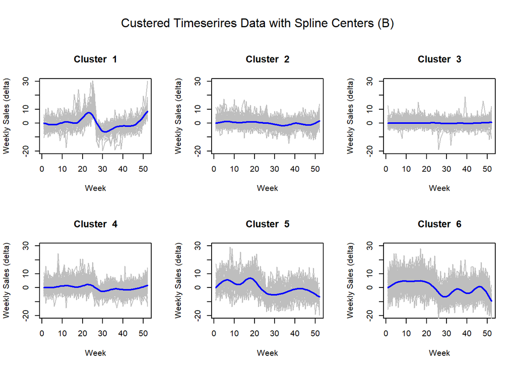

```r
#6 clusters per instructions
cluster_count = 6

# get clusters
clusters = kmeans(B, centers=cluster_count)

# initialize new plot with 6 windows, add some margin for title
par(mfrow = c(2, 3), oma = c(0, 0, 4, 0))

# iterate through clusters, plot each one
for (cluster in 1:cluster_count) {
  # get data for this cluster
  x_cluster = X[clusters$cluster == cluster, ]
  b_cluster = B[clusters$cluster == cluster, ]

  # convert b spline back to timeseries
  b = colMeans(b_cluster)
  spline_plot = f %*% b

  plot(x=weeks,
       y=spline_plot,
       main=paste('Cluster ', cluster),
       ylab='Weekly Sales (delta)',
       xlab='Week',
       ylim=c(-20, 30),
       col='blue',
       type = 'l')

  # plot each x in this cluster
  for (series in 1:nrow(x_cluster)) {
    lines(x=weeks,
          y=x_cluster[series, ],
          col="gray")
  }

  # now plot the cluster center again for visibility (so its 'on top')
  lines(x=weeks,
        y=spline_plot,
        col="blue",
        lwd=2)
}

# add main title to top
mtext('Custered Timeserires Data with Spline Centers (B)', side=3, line=1, outer=TRUE)
```

Part 2-3: Clustering using Matrix X

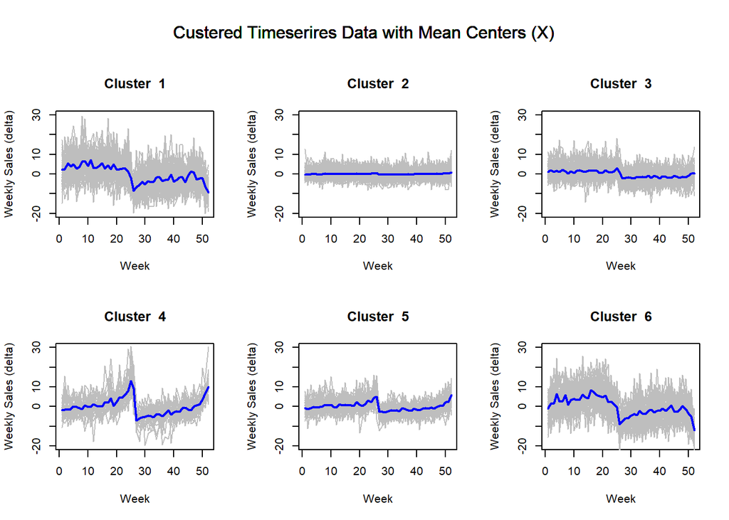

```r
# get clusters
clusters = kmeans(X, centers=cluster_count)

# initialize new plot with 6 windows, add some margin for title
par(mfrow = c(2, 3), oma = c(0, 0, 4, 0))

# iterate through clusters, plot each one
for (cluster in 1:cluster_count) {
  # get data for this cluster
  x_cluster = X[clusters$cluster == cluster, ]

  # this time spline plot is mean of clusters
  center_plot = colMeans(x_cluster)

  plot(x=weeks,
       y=center_plot,
       main=paste('Cluster ', cluster),
       ylab='Weekly Sales (delta)',
       xlab='Week',
       ylim=c(-20, 30),
       col='blue',
       type = 'l')

  # plot each x in this cluster
  for (series in 1:nrow(x_cluster)) {
    lines(x=weeks,
          y=x_cluster[series, ],
          col="grey")
  }

  # now plot the cluster center again for visibility (so its 'on top')
  lines(x=weeks,
        y=center_plot,
        col="blue",
        lwd=2)

# add main title to top
mtext('Custered Timeserires Data with Mean Centers (X)', side=3, line=1, outer=TRUE)

}
```

# Part 3: Ridgeless and double descent

## Part 3-1: Ridgeless Function

```r
# set seed
set.seed(235)

# from assignment, recommended threshold for excluding eigen values
eps = 1e-10

part3_data = read.csv('Coding3_dataH.csv',header = FALSE)

data = as.matrix(part3_data)

ridgeless = function(train, test){
# partition into X and Y
trainX = train[,-1]
trainY = train[,1]
testX = test[,-1]
testY = test[,1]


# do PCA on train (note this is doing centering for us I think)
pca = prcomp(trainX, scale = FALSE, center = TRUE)
components = pca$sdev

# throw away any components that are worse than professor-defined eps
selected = which(abs(components) > eps)

# now extract selected features
trainX_principal = pca$x[, selected]

# now do ridgeless regression (?)
lambda = diag(1/diag(t(trainX_principal) %*% trainX_principal))
beta = lambda %*% t(trainX_principal) %*% trainY

# from prof, we need to take the intercept here in order to add it back after
b0 = mean(trainY)

# get train error
trainY_pred = b0 + trainX_principal %*% beta
train_error = log(mean(sqrt(sum(trainY - trainY_pred)^2)))

# get test error
testX_principal = predict(pca, newdata=testX)[, selected]
testY_pred = b0 + testX_principal %*% beta

test_error = log(mean(sqrt(sum(testY - testY_pred)^2)))

# return both train and test, as suggested
return(c(train_error, test_error))
}
```

## Part 3-2: Simulation study

Graphical display: Plot the median of the test errors (collated over the 30 iterations) in log scale against the count of regression parameters, which spans from 5 to 240.

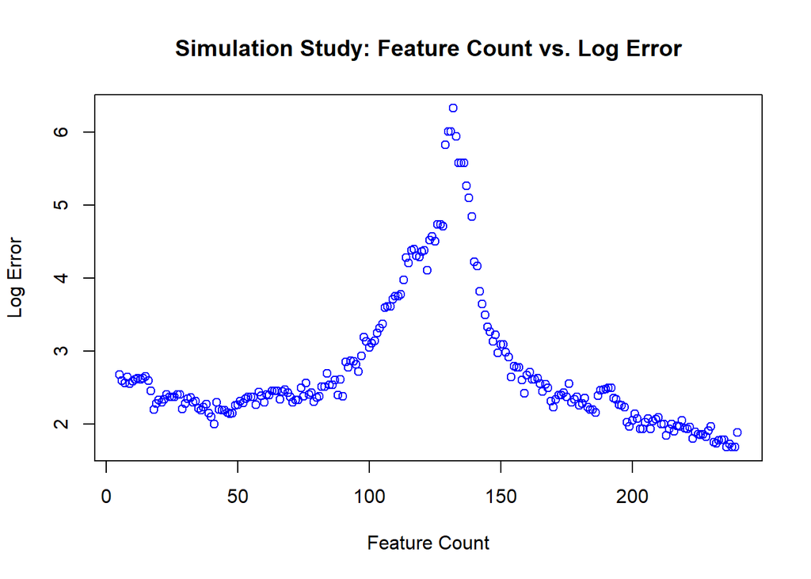

```r
# params for simulation
n_sims = 30
p_train = .25
n_train = round(nrow(data) * p_train)
d_vals = 6:241

# preallocate data collection
errors = matrix(0, nrow=n_sims, ncol=length(d_vals))

#iterate, run each simulation
for (sim in 1:n_sims) {
  # partition data
  train_idx = sample(1:nrow(data), n_train)
  train = data[train_idx, ]
  test = data[-train_idx, ]

  # iterate through values of d
  for (d in 1:length(d_vals)) {
    # subset data to only account for first d params
    train_subset = train[ ,1:d_vals[d]]
    test_subset = test[ ,1:d_vals[d]]

    # Call ridgeless, only keep test error
    error = ridgeless(train_subset, test_subset)[2]

    errors[sim, d] = error
  }
}

# average across simulations
sim_output = apply(errors, 2, median)

plot(x=d_vals-1,
     y=sim_output,
     main=paste('Simulation Study: Feature Count vs. Log Error'),
     ylab='Log Error',
     xlab='Feature Count',
     col='blue'
     )
```